# R Notebook

```r
# instalar paquetes
install.packages("tidyverse")
install.packages("dplyr")
install.packages("ggplot2")
install.packages("devtools")


#cargar paquetes
library(tidyverse)
library(dplyr)
library(ggplot2)
library(car)
library(devtools)
library(cowplot)
library(reshape2)
```

### Carga y Limpieza de Datos:

```r
#Leer el fichero
data = read.csv("./data.csv", sep=',')
data <- data
# renombrar las columnas del data frame
names(data) <- tolower(names(data))
names(data) <- gsub(" ", "", names(data))

# Usamos la funcion glimpse() para obtener un resumen del contenido del data set
glimpse(data)
```

```
Rows: 6,819
Columns: 96
$ bankrupt.                                               <int> 1, 1, 1, 1, 1, 1, 0, 0, 0, 0, 0…
$ roa.c..before.interest.and.depreciation.before.interest <dbl> 0.3705943, 0.4642909, 0.4260713…
$ roa.a..before.interest.and...after.tax                  <dbl> 0.4243894, 0.5382141, 0.4990188…
$ roa.b..before.interest.and.depreciation.after.tax       <dbl> 0.4057498, 0.5167300, 0.4722951…
$ operating.gross.margin                                  <dbl> 0.6014572, 0.6102351, 0.6014500…
$ realized.sales.gross.margin                             <dbl> 0.6014572, 0.6102351, 0.6013635…
$ operating.profit.rate                                   <dbl> 0.9989692, 0.9989460, 0.9988574…
$ pre.tax.net.interest.rate                               <dbl> 0.7968871, 0.7973802, 0.7964034…
$ after.tax.net.interest.rate                             <dbl> 0.8088094, 0.8093007, 0.8083875…
$ non.industry.income.and.expenditure.revenue             <dbl> 0.3026464, 0.3035564, 0.3020352…
$ continuous.interest.rate..after.tax.                    <dbl> 0.7809849, 0.7815060, 0.7802839…
$ operating.expense.rate                                  <dbl> 1.256969e-04, 2.897851e-04, 2.3…
$ research.and.development.expense.rate                   <dbl> 0.00e+00, 0.00e+00, 2.55e+07, 0…
```

[output cut: 83 more lines]

Observamos que el data set tiene 6,819 filas y 96 columnas.

Los datos categoricos aparecen como tipo integer (int) y los datos numericos como tipo double (dbl).

```r
# revisamos si hay missing values

sum(is.na(data))
```

```
[1] 0
```

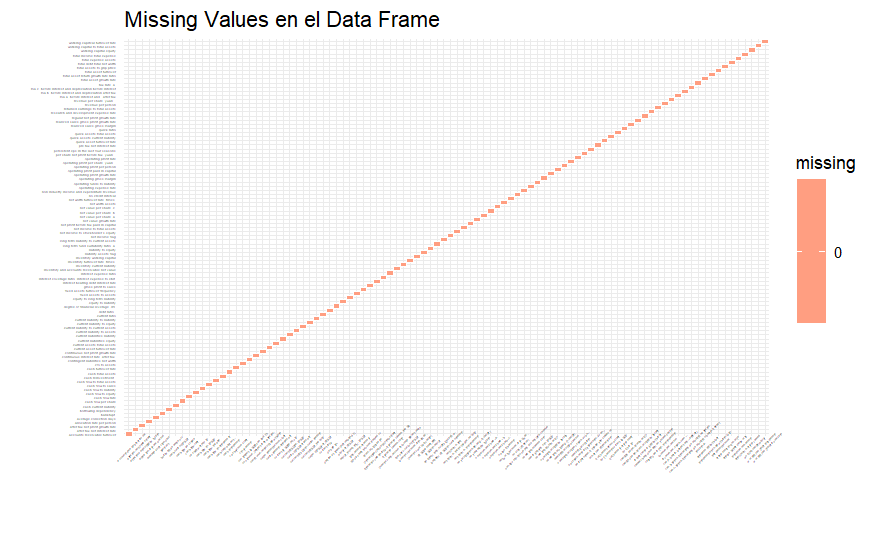

```r
# visualmente se puede hacer de esta forma

# crear un data frame con los missing values para cada columna
missing <- data.frame(colSums(is.na(data)))
names(missing) <- "missing"
missing$variable <- rownames(missing)

# create a heatmap usando ng the ggplot2 package
ggplot(missing, aes(variable, reorder(variable, -missing))) +
  geom_tile(aes(fill = missing), color = "white") +
  scale_fill_gradient(low = "white", high = "red") +
  labs(title = "Missing Values en el Data Frame",
       x = "", y = "") +
  theme_minimal() +
  theme(axis.text.x = element_text(angle = 45, vjust = 1, size = 2),
        axis.text.y = element_text(size = 2))
```

Observamos que el dataser no tiene missing values, por lo que podemos pasar a analizar la data.

### Visualizacion de los Datos:

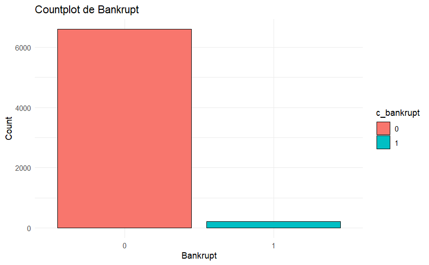

```r
c_bankrupt <- as.factor(data$bankrupt)

# create a bar plot using the ggplot2 package
ggplot(data, aes(x = c_bankrupt, fill = c_bankrupt)) +
  geom_bar(color = "black") +
  labs(title = "Countplot de Bankrupt",
       x = "Bankrupt", y = "Count") +
  theme_minimal()
```

Se puede observar que los registros de “Bankrupt” estan muy desbalanceados. Por lo que es necesario considerar balancear el dataset usando tecnicas como Upsampling y Downsampling.

Cuando usamos la funcion glimplse() para obtener un resumen de los datos del data set, observamos que la mayoria de los datos eran de tipo double (dbl). Los datos categoricos son distinguidos de forma binaria (1 y 0), por lo que aparecen como tipo integer (int).

Separemos los datos numericos de los datos categoricos para analizar el dataser:

```r
# identificamos y separamos la data segun tipo

double_features <- data %>% select_if(is.double)

categorical_features <- data %>% select_if(is.integer)

categorical_columns <- names(categorical_features)

categorical_columns
```

```
[1] "bankrupt."             "liability.assets.flag" "net.income.flag"
```

El dataset solo contiene 3 columnas con valores categoricos. Exploremos estas columnas primero:

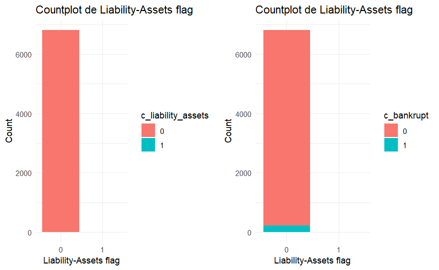

```r
c_liability_assets <- as.factor(data$liability.assets.flag)

# crear primer bar plot
p1 <- ggplot(data, aes(x = c_liability_assets, fill = c_liability_assets)) +
  geom_bar() +
  labs(title = "Countplot de Liability-Assets flag",
       x = "Liability-Assets flag", y = "Count") +
  theme_minimal()

# crear segundo bar plot
p2 <- ggplot(data, aes(x = c_liability_assets, fill = c_bankrupt)) +
  geom_bar() +
  labs(title = "Countplot de Liability-Assets flag",
       x = "Liability-Assets flag", y = "Count") +
  theme_minimal()

plot_grid(p1,p2)
```

```r
data %>% count(liability.assets.flag)
```

| liability.assets.flag | n |
| --- | --- |
| 0 | 6811 |
| 1 | 8 |

```r
NA
```

El indicador “Liability-Assets” (“Activos-Pasivos”) denota el estado de una organizacion, donde si los pasivos totales exceden los activos totales, el valor marcado sera 1, de lo contrario, el valor sera 0.

-La mayoria de las veces, los activos de las empresas u organizaciones son mayores que sus pasivos.

-Una pequeña parte de las organizaciones llegan a la bancarrota, aunque tengan mas activos que pasivos.

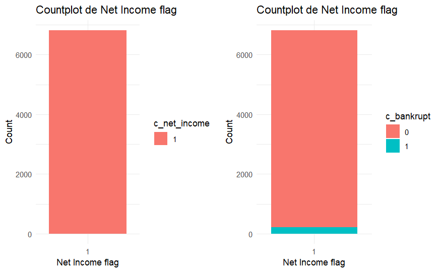

```r
c_net_income <- as.factor(data$net.income.flag)

# create a bar plot using the ggplot2 package
p1 <- ggplot(data, aes(x = c_net_income, fill = c_net_income)) +
  geom_bar() +
  labs(title = "Countplot de Net Income flag",
       x = "Net Income flag", y = "Count") +
  theme_minimal()

# create a bar plot using the ggplot2 package
p2 <- ggplot(data, aes(x = c_net_income, fill = c_bankrupt)) +
  geom_bar() +
  labs(title = "Countplot de Net Income flag",
       x = "Net Income flag", y = "Count") +
  theme_minimal()

plot_grid(p1,p2)
```

```r
data %>% count(net.income.flag)
```

| net.income.flag | n |
| --- | --- |
| 1 | 6819 |

```r
NA
```

El indicador de “Net Income” (“Ingresos Netos”) denota el estado de los ingresos de una organización en los últimos dos años, donde si los ingresos netos son negativos durante los últimos dos años, el valor marcado será 1, de lo contrario el valor es 0.

-Observamos que todos los los registros han estado exhibiendo una pérdida durante los últimos dos años.

-Muchas organizaciones que han sufrido pérdidas durante los últimos dos años han estabilizado su negocio, evitando llegar a la bancarrota.

```r
# obtenemos la correlacion entre las columnas numericas y la columna "Bankrupt"

correlaciones <- cor(data[,colnames(double_features)], data["bankrupt."])

correlaciones[order(correlaciones),,drop=FALSE]
```

```
                                                            bankrupt.
net.income.to.total.assets                              -0.3154569716
roa.a..before.interest.and...after.tax                  -0.2829405849
roa.b..before.interest.and.depreciation.after.tax       -0.2730513179
roa.c..before.interest.and.depreciation.before.interest -0.2608065575
net.worth.assets                                        -0.2501609621
persistent.eps.in.the.last.four.seasons                 -0.2195596812
retained.earnings.to.total.assets                       -0.2177787800
net.profit.before.tax.paid.in.capital                   -0.2078565200
per.share.net.profit.before.tax..yuan...                -0.2013948345
working.capital.to.total.assets                         -0.1930833758
net.income.to.stockholder.s.equity                      -0.1809869884
net.value.per.share..a.                                 -0.1654647588
net.value.per.share..b.                                 -0.1653990211
net.value.per.share..c.                                 -0.1647839235
working.capital.equity                                  -0.1472208765
operating.profit.per.share..yuan...                     -0.1420505822
operating.profit.paid.in.capital                        -0.1411113238
cfo.to.assets                                           -0.1153831090
tax.rate..a.                                            -0.1097056692
cash.total.assets                                       -0.1001301899
gross.profit.to.sales                                   -0.1000438475
operating.gross.margin                                  -0.1000432441
realized.sales.gross.margin                             -0.0994452496
operating.profit.per.person                             -0.0928421410
quick.assets.total.assets                               -0.0863821115
equity.to.liability                                     -0.0830484458
cash.flow.per.share                                     -0.0775164598
operating.funds.to.liability                            -0.0770819609
cash.flow.rate                                          -0.0723555512
cash.flow.to.total.assets                               -0.0704556451
total.asset.turnover                                    -0.0679151672
cash.flow.to.equity                                     -0.0585632742
cash.reinvestment..                                     -0.0513452043
current.assets.total.assets                             -0.0448233389
total.asset.growth.rate                                 -0.0444310214
cash.flow.to.liability                                  -0.0431250482
after.tax.net.profit.growth.rate                        -0.0377829729
regular.net.profit.growth.rate                          -0.0368196768
research.and.development.expense.rate                   -0.0242319684
```

[output cut: 39 more lines]

```
net.value.growth.rate                                    0.0653294244
fixed.assets.to.assets                                   0.0663283549
contingent.liabilities.net.worth                         0.0704545248
fixed.assets.turnover.frequency                          0.0728182642
inventory.and.accounts.receivable.net.value              0.0752780821
cash.current.liability                                   0.0779210962
equity.to.long.term.liability                            0.1390135725
total.expense.assets                                     0.1390492160
current.liabilities.equity                               0.1538283619
current.liability.to.equity                              0.1538283619
liability.to.equity                                      0.1668120978
current.liability.to.current.assets                      0.1713060435
borrowing.dependency                                     0.1765429362
current.liability.to.assets                              0.1944944359
debt.ratio..                                             0.2501609621
```

Por simplicidad, analizaremoss los seis atributos con mayor correlacion positiva y negativa.

```r
corr_positiva <- rev(tail(rownames(correlaciones[order(correlaciones),,drop=FALSE]),6))
corr_negativa <- rownames(correlaciones[order(correlaciones),,drop=FALSE])[1:6]


corr_positiva <- data[, c(corr_positiva, "bankrupt.")]
corr_negativa <- data[, c(corr_negativa, "bankrupt.")]

colnames(corr_positiva)
```

```
[1] "debt.ratio.."                        "current.liability.to.assets"
[3] "borrowing.dependency"                "current.liability.to.current.assets"
[5] "liability.to.equity"                 "current.liability.to.equity"
[7] "bankrupt."
```

```r
colnames(corr_negativa)
```

```
[1] "net.income.to.total.assets"
[2] "roa.a..before.interest.and...after.tax"
[3] "roa.b..before.interest.and.depreciation.after.tax"
[4] "roa.c..before.interest.and.depreciation.before.interest"
[5] "net.worth.assets"
[6] "persistent.eps.in.the.last.four.seasons"
[7] "bankrupt."
```

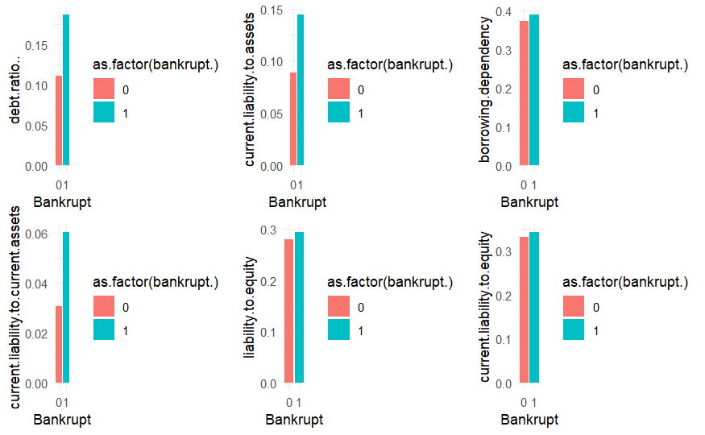

```r
# Calcular correlacion media para cada columna
df_mean_p1 <- corr_positiva %>% group_by(bankrupt.) %>% summarize(mean_p1 = mean(debt.ratio..))
df_mean_p2 <- corr_positiva %>% group_by(bankrupt.) %>% summarize(mean_p2 = mean(current.liability.to.assets))
df_mean_p3 <- corr_positiva %>% group_by(bankrupt.) %>% summarize(mean_p3 = mean(borrowing.dependency))
df_mean_p4 <- corr_positiva %>% group_by(bankrupt.) %>% summarize(mean_p4 = mean(current.liability.to.current.assets))
df_mean_p5 <- corr_positiva %>% group_by(bankrupt.) %>% summarize(mean_p5 = mean(liability.to.equity))
df_mean_p6 <- corr_positiva %>% group_by(bankrupt.) %>% summarize(mean_p6 = mean(current.liability.to.equity))

# Crear a barplots
plot_grid(ggplot(df_mean_p1, aes(x=as.factor(bankrupt.), y=mean_p1, fill=as.factor(bankrupt.))) + geom_col() + theme_minimal() + labs( x = "Bankrupt", y = "debt.ratio.."),
ggplot(df_mean_p2, aes(x=as.factor(bankrupt.), y=mean_p2, fill=as.factor(bankrupt.))) + geom_col() + theme_minimal() + labs( x = "Bankrupt", y = "current.liability.to.assets"),
ggplot(df_mean_p3, aes(x=as.factor(bankrupt.), y=mean_p3, fill=as.factor(bankrupt.))) + geom_col() + theme_minimal() + labs( x = "Bankrupt", y = "borrowing.dependency"),
ggplot(df_mean_p4, aes(x=as.factor(bankrupt.), y=mean_p4, fill=as.factor(bankrupt.))) + geom_col() + theme_minimal() + labs( x = "Bankrupt", y = "current.liability.to.current.assets"),
ggplot(df_mean_p5, aes(x=as.factor(bankrupt.), y=mean_p5, fill=as.factor(bankrupt.))) + geom_col() + theme_minimal() + labs( x = "Bankrupt", y = "liability.to.equity"),
ggplot(df_mean_p6, aes(x=as.factor(bankrupt.), y=mean_p6, fill=as.factor(bankrupt.))) + geom_col() + theme_minimal() + labs( x = "Bankrupt", y = "current.liability.to.equity"), nrow = 2, ncol = 3)
```

Observamos que los 3 atributos: “Debt Ratio %”, “Current Liability to Assets” y “Current Liability to Current Assets” son comunmente altos en organizaciones o empresas que llegan a la bancarrota.

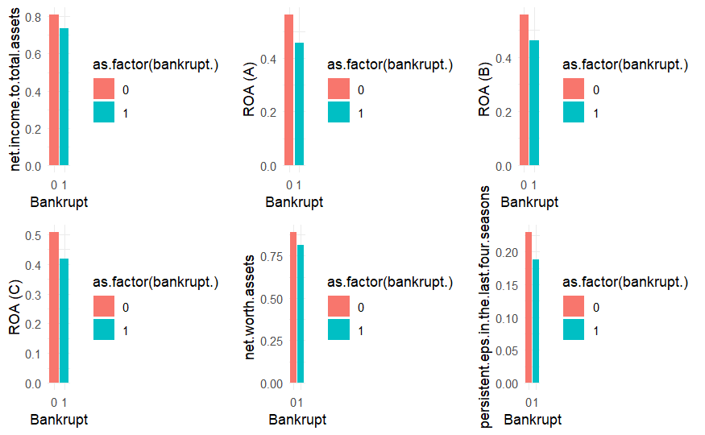

```r
# Calcular correlacion media para cada columna
df_mean_p1 <- corr_negativa %>% group_by(bankrupt.) %>% summarize(mean_p1 = mean(net.income.to.total.assets))
df_mean_p2 <- corr_negativa %>% group_by(bankrupt.) %>% summarize(mean_p2 = mean(roa.a..before.interest.and...after.tax))
df_mean_p3 <- corr_negativa %>% group_by(bankrupt.) %>% summarize(mean_p3 = mean(roa.b..before.interest.and.depreciation.after.tax))
df_mean_p4 <- corr_negativa %>% group_by(bankrupt.) %>% summarize(mean_p4 = mean(roa.c..before.interest.and.depreciation.before.interest))
df_mean_p5 <- corr_negativa %>% group_by(bankrupt.) %>% summarize(mean_p5 = mean(net.worth.assets))
df_mean_p6 <- corr_negativa %>% group_by(bankrupt.) %>% summarize(mean_p6 = mean(persistent.eps.in.the.last.four.seasons))

# Crear a barplots
plot_grid(ggplot(df_mean_p1, aes(x=as.factor(bankrupt.), y=mean_p1, fill=as.factor(bankrupt.))) + geom_col() + theme_minimal() + labs( x = "Bankrupt", y = "net.income.to.total.assets"),
ggplot(df_mean_p2, aes(x=as.factor(bankrupt.), y=mean_p2, fill=as.factor(bankrupt.))) + geom_col() + theme_minimal() + labs( x = "Bankrupt", y = "ROA (A)"),
ggplot(df_mean_p3, aes(x=as.factor(bankrupt.), y=mean_p3, fill=as.factor(bankrupt.))) + geom_col() + theme_minimal() + labs( x = "Bankrupt", y = "ROA (B)"),
ggplot(df_mean_p4, aes(x=as.factor(bankrupt.), y=mean_p4, fill=as.factor(bankrupt.))) + geom_col() + theme_minimal() + labs( x = "Bankrupt", y = "ROA (C)"),
ggplot(df_mean_p5, aes(x=as.factor(bankrupt.), y=mean_p5, fill=as.factor(bankrupt.))) + geom_col() + theme_minimal() + labs( x = "Bankrupt", y = "net.worth.assets"),
ggplot(df_mean_p6, aes(x=as.factor(bankrupt.), y=mean_p6, fill=as.factor(bankrupt.))) + geom_col() + theme_minimal() + labs( x = "Bankrupt", y = "persistent.eps.in.the.last.four.seasons"), nrow = 2, ncol = 3)
```

En general, estos atributos nos muestran que cuantos mas activos y ganancias tiene una organizacion, menos probable es que esta llegue a la bancarrota.

Ahora veamos la relacion entre los 6 atributos con mas correlacion positiva y negativa entre ellos mismos.

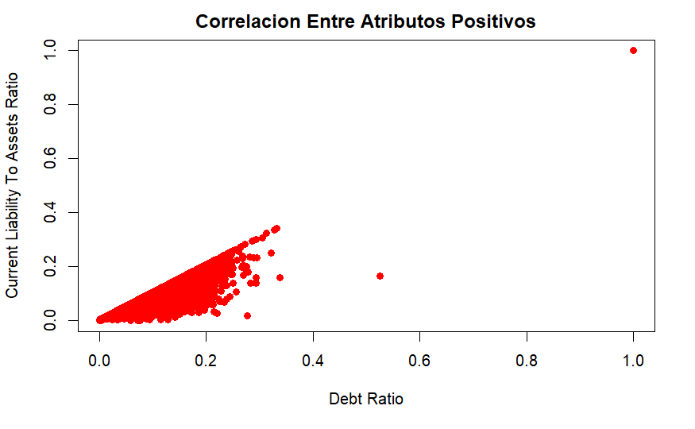

```r
# Create first plot
plot(x = data$debt.ratio.., y = data$current.liability.to.assets, xlab = "Debt Ratio", ylab = "Current Liability To Assets Ratio", pch = 19, col = "red", main = "Correlacion Entre Atributos Positivos")
```

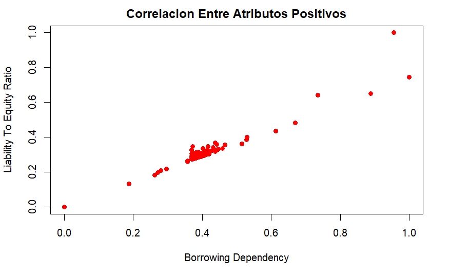

```r
# Create second plot
plot(x = data$borrowing.dependency, y = data$liability.to.equity, xlab = "Borrowing Dependency", ylab = "Liability To Equity Ratio", pch = 19, col = "red", main = "Correlacion Entre Atributos Positivos")
```

Se observa una relación positiva entre los atributos que tienen una alta correlación con el atributo objetivo (“Bankrupt”).

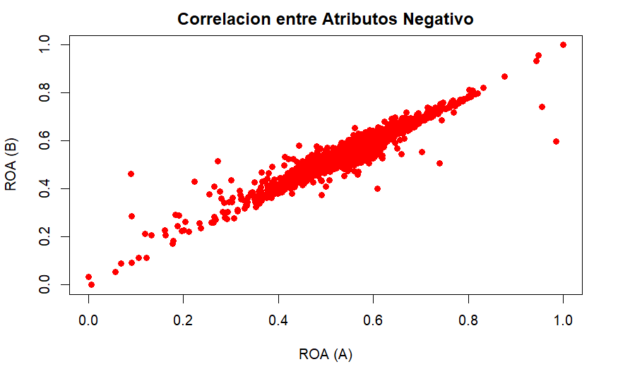

```r
# Crear primer plot
plot(x = data$roa.a..before.interest.and...after.tax, y = data$roa.b..before.interest.and.depreciation.after.tax, xlab = "ROA (A)", ylab = "ROA (B)", pch = 19, col = "red", main = "Correlacion entre Atributos Negativo")
```

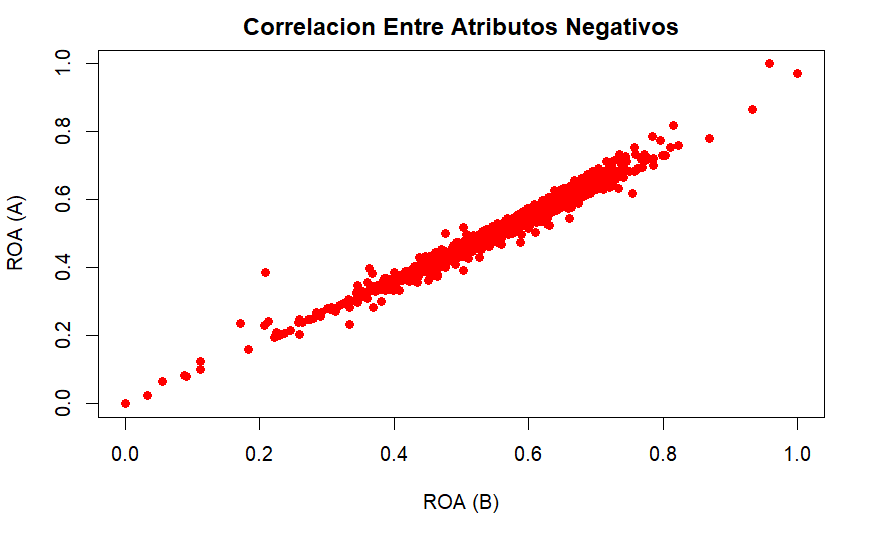

```r
# Crear segundo plot
plot(x = data$roa.b..before.interest.and.depreciation.after.tax, y = data$roa.c..before.interest.and.depreciation.before.interest, xlab = "ROA (B)", ylab = "ROA (A)", pch = 19, col = "red", main = "Correlacion Entre Atributos Negativos")
```

Se observa una relación positiva entre los atributos que tienen una baja correlación con el atributo objetivo (“Bakrupt”).

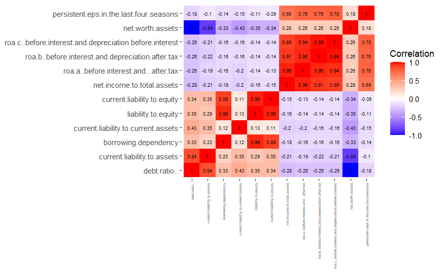

```r
# Creamos matriz de correlaciones con los top 6 con mayor correlacion y los top 6 con menor correlacion
relacion <- c(colnames(corr_positiva)[1:6], colnames(corr_negativa)[1:6])
top_cor <- cor(data[,relacion])

# Crear Heatmap de correlacion
melted_cormat <- melt(top_cor)

ggplot(data = melted_cormat, aes(x=Var2, y=Var1, fill=value)) +
  geom_tile() +
  geom_text(aes(Var2, Var1, label = round(value, 2)), size = 2) +
  scale_fill_gradient2(low = "blue", high = "red",
                       limit = c(-1,1), name="Correlation") +
  theme(axis.text.x = element_text(angle = 90, vjust = 0.5, hjust = 1, size = 4),
        axis.title.x = element_blank(),
        axis.title.y = element_blank(),
        panel.background = element_blank())
```

Observamos varias correlaciones entre los top 12 atributos principales, una de las cuales es “Net Wortg Assets” y “Debt Ratio” que estan negativamente correlacionada entre sí.